# Homework - Jiaming Huang

## Statistics warm-up

Consider a random variable $X$ with a probability density function

$$f(x) = \frac{c}{\sqrt{x(b-x)}}, \quad 0<x<b,$$
where $c$ is a normalising constant and $b$ is a parameter.

- **Question**: Find $c$ such that the probability density function is valid.

  **Solutions**:  
  To have a probability density function valid, it must satisfies two requirements:
  1. $f(x) \ge 0$ , which means $c \ge 0$
  2. $\int_{0}^{b}f(x)dx = 1$,

$$\begin{aligned}
\int_{0}^{b}f(x)dx &= \int_{0}^{b}\frac{c}{\sqrt{x(b-x)}}dx = c\int_{0}^{b}\frac{1}{\sqrt{\frac{b^2}{4}-(x-\frac{b}{2})^2}}dx \\
&=c\int_{0}^{b}\frac{1}{\sqrt{\frac{b^2}{4}-(x-\frac{b}{2})^2}}d(x-\frac{b}{2})\\
\end{aligned}$$

let $x-\frac{b}{2}=\frac{b}{2}sin(u)$, so $u=arcsin(\frac{2x}{b}-1)$. Because $0<x<b$, then $-\frac{\pi}{2}<u<\frac{\pi}{2}$

Then further,
$$\begin{aligned}
\int_{0}^{b}f(x)dx &= c\int_{-\frac{\pi}{2}}^{\frac{\pi}{2}}\frac{1}{\sqrt{\frac{b^2}{4}-\frac{b^2}{4}(\sin(u))^2}}d\frac{b}{2}\sin(u) \\
&=c\int_{-\frac{\pi}{2}}^{\frac{\pi}{2}}\frac{1}{\sqrt{1-(\sin(u))^2}}d\sin(u) = c\int_{-\frac{\pi}{2}}^{\frac{\pi}{2}}\frac{1}{|\cos(u)|}\cos(u)du
\end{aligned}$$

Because when $-\frac{\pi}{2}<u<\frac{\pi}{2}$, $cos(u)$ is a positive value, therefore,
$$\begin{aligned}
\int_{0}^{b}f(x)dx &=c\int_{-\frac{\pi}{2}}^{\frac{\pi}{2}}du=cu|^\frac{\pi}{2}_{-\frac{\pi}{2}}=\pi c, \text{which equals to 1}\\
&\text{therefore}, c=\frac{1}{\pi}
\end{aligned}$$

- **Question**: Find the corresponding cumulative distribution function, $F(x)$ and its inverse $F^{-1}(x)$.

  **Solutions**: $F(x) = P(X\le x) = \int_{-\infty}^{x}f(x)dx$ = $\frac{1}{\pi}\int_{0}^{x}\frac{1}{\sqrt{x(b-x)}}dx$ similiar to the process above, then we get the cumulative distribution function,

  $F(x)=\frac{1}{\pi}\int_{-\frac{\pi}{2}}^{\arcsin(\frac{2x}{b}-1)}du = \frac{\arcsin(\frac{2x}{b}-1)}{\pi}+\frac{1}{2}, \quad 0<x<b$

  To compute the inverse function $F^{-1}(x)$, we can just let $y = \frac{\arcsin(\frac{2x}{b}-1)}{\pi}+\frac{1}{2}$, where when $0<x<b$, then $0<y<1$

  Exchange $x$ and $y$, then we have $x = \frac{\arcsin(\frac{2y}{b}-1)}{\pi}+\frac{1}{2}$, where $0<x<1$

$$\begin{aligned}
&x=\frac{\arcsin(\frac{2y}{b}-1)}{\pi}+\frac{1}{2},\\ &\text{therefore},
\pi x-\frac{\pi}{2}=\arcsin(\frac{2y}{b}-1), \\ &\text{then},
\sin(\pi x -\frac{\pi}{2})=\frac{2y}{b}-1,
\\ &\text{finally, we get}, F^{-1}(x)=y=\frac{b(\sin(\pi x-\frac{\pi}{2})+1)}{2}, \text{where} \quad 0<x<1
\end{aligned}$$

- **Question**: Describe a procedure to generate samples distributed according to $X$, given a set of uniformly distributed samples $u_1,\dots,u_n \sim \mathcal{U}[0,1]$.

  **Solutions**: Just directly plug this set of uniformly distributed samples into the inverse function $F^{-1}(x)$ as described above.
- **Question**: Set the seed to 42 and generate 1,000 samples distributed according to $X$ using 1,000 uniformly distributed i.i.d. $\mathcal{U}[0,1]$ samples, with $b=5$. Plot a histogram of the resulting samples.

  **Solutions**:

```r
set.seed(42)
uniform_samples <- runif(1000, min = 0, max = 1)
```

When $b=5$, $F^{-1}(x)=\frac{5(\sin(\pi x-\frac{\pi}{2})+1)}{2}$, then we plug the 1,000 uniform distributed samples generated above into the inverse function $F^{-1}(x)$

```r
b <- 5

simulation_results <- b*(sin(pi * uniform_samples-pi/2)+1)/2

# check the distribution of the simulated samples
max(simulation_results) < b
```

```
## [1] TRUE
```

```r
min(simulation_results) > 0
```

```
## [1] TRUE
```

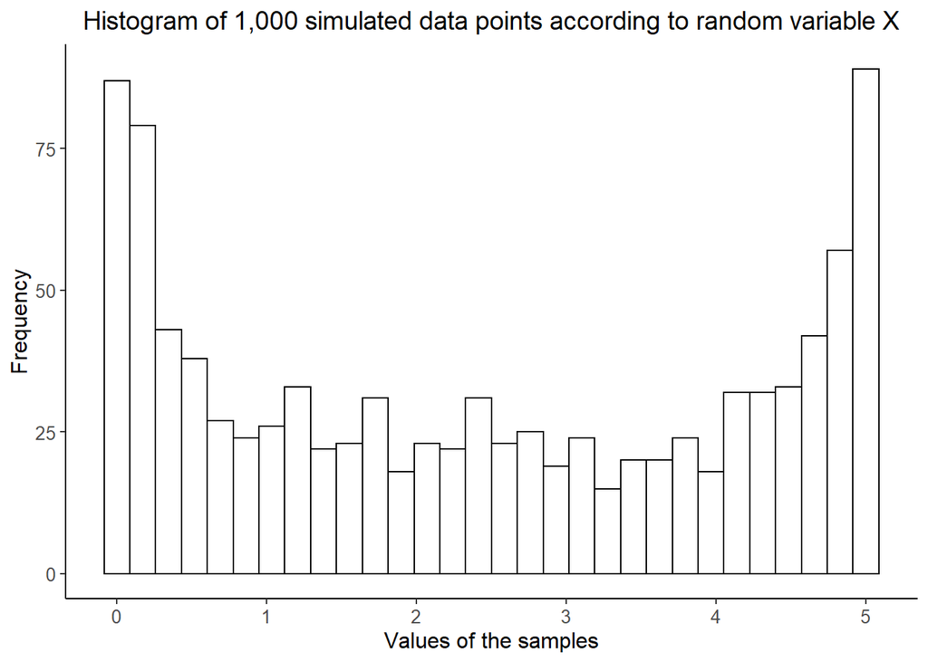

```r
results <- data.frame(id = 1:1000, values = simulation_results)
library(ggplot2)
ggplot(results) +
  geom_histogram(aes(x = values), color = "black", fill = "white", bins = 30) +
  ggtitle("Histogram of 1,000 simulated data points according to random variable X") +
  xlab("Values of the samples") +
  ylab("Frequency") +
  theme(plot.title = element_text(hjust = 0.5, size = 14),
        axis.text = element_text(size = 10),
        axis.title = element_text(size = 12),
        panel.background = element_blank(),
        axis.line = element_line(color = "black"))
```

- **Question**: Assume that we have a set of samples $X_1,\dots,X_n$ which are i.i.d. as $X$ with $b$ unknown. Find the log-likelihood function for the parameter $b$, $\ell(b;x_1,\dots,x_n)$ and find its derivative with respect to $b$, $\frac{d\ell}{db}$.

  **Solutions** Right now, we have the density function $f(x; b) = \frac{1}{\pi \sqrt{x(b-x)}}, \quad 0<x<b$, then the likelihood function is:

$$\begin{aligned}
L(b) &= \prod_{i=1}^{n}\frac{1}{\pi \sqrt{x_i(b-x_i)}}, \quad \text{let}\quad l(b)=lnL(b), \quad \text{then the log-likelihood function is} \\
l(b) &= \sum_{i=1}^{n}ln\frac{1}{\pi \sqrt{x_i(b-x_i)}} = -\sum_{i=1}^{n}ln(\pi \sqrt{x_i(b-x_i)})=-nln\pi-\frac{1}{2}\sum_{i=1}^{n}ln(x_i(b-x_i))\\
&=-nln\pi-\frac{1}{2}\sum_{i=1}^{n}ln(x_i) - \frac{1}{2}\sum_{i=1}^{n}ln(b-x_i)
\end{aligned}$$

Then the derivative with respect to $b$, $\frac{d\ell}{db}$, is:
$$\begin{aligned}
\frac{d\ell}{db} &= \frac{d(-nln\pi-\frac{1}{2}\sum_{i=1}^{n}ln(x_i) - \frac{1}{2}\sum_{i=1}^{n}ln(b-x_i))}{db} \\
&=-\frac{1}{2}\frac{d(\sum_{i=1}^{n}ln(b-x_i))}{db}\\
&=-\frac{1}{2}\sum_{i=1}^{n}\frac{d(ln(b-x_i))}{db}\\
&=-\frac{1}{2}\sum_{i=1}^{n}\frac{1}{b-x_i}
\end{aligned}$$

- **Question**: Based on the likelihood, or otherwise, give a statistic based on $X_1,\dots,X_n$ which is a reasonable estimator for the unknown parameter $b$. Explain your choice.

  **Solutions**: Based on the log-likelihood function and the first derivarite of the log-likelihood function derived above, we can see that the likelihood function of $b$ is **monotonically decreasing** when $0<x<b$, the function has its maximum likelihood when $b$ has its smallest available value. Therefore, a reasonable estimator for $b$ is the $\max(X_1,\dots,X_n)$.
- **Question**: The file `samples.rds` contains samples $X_1,\dots,X_n$ distributed according to $X$. Report the estimated value of $\hat{b}$ based on those samples.

  **Solutions**:

```r
library(readr)
samples <- read_rds(file = "C:/Users/jh2874/Box/Jiaming Huang/interview/samples.rds")

# the MLE of parameter b is the largest value of the X samples
print(b <- max(samples))
```

```
## [1] 85.19952
```

Therefore, the $\hat{b}_{MLE}=85.19952$

## Arrays

You are given a multi-dimensional array `array.rds`. It contains penetrance curves for various cancers and genes. In simple terms, penetrances are how likely one will develop a cancer given that they have a certain corresponding gene mutation. Other variables in `data` describe different sub-populations. For example, the probabilities corresponding to `Brain` cancer and gene `APC` are the probabilities for which a person will develop brain cancer, given that they have a mutation in the `APC` gene.

- **Question**: Read in the data and give the dimensions of the array.

*Hint: Use the `str` function.*

**Solutions**:

```r
array <- read_rds(file = "C:/Users/jh2874/Box/Jiaming Huang/interview/array.rds")
str(array)
```

```
##  num [1:18, 1:26, 1:8, 1:2, 1:94] 3.98e-05 2.80e-07 0.00 5.00e-08 0.00 ...
##  - attr(*, "dimnames")=List of 5
##   ..$ Cancer: chr [1:18] "Brain" "Breast" "Cervical" "Colorectal" ...
##   ..$ Gene  : chr [1:26] "APC" "ATM" "BARD1" "BMPR1A" ...
##   ..$ Race  : chr [1:8] "All_Races" "AIAN" "Asian" "Black" ...
##   ..$ Sex   : chr [1:2] "Female" "Male"
##   ..$ Age   : chr [1:94] "1" "2" "3" "4" ...
```

The dimension of the array is:

```r
dim(array)
```

```
## [1] 18 26  8  2 94
```

- **Question**: Subset the array for the penetrances associated with `Breast` cancer and the `BRCA2` gene for a female with the default race `All_Races`. Then plot the penetrance curve (probability versus age).

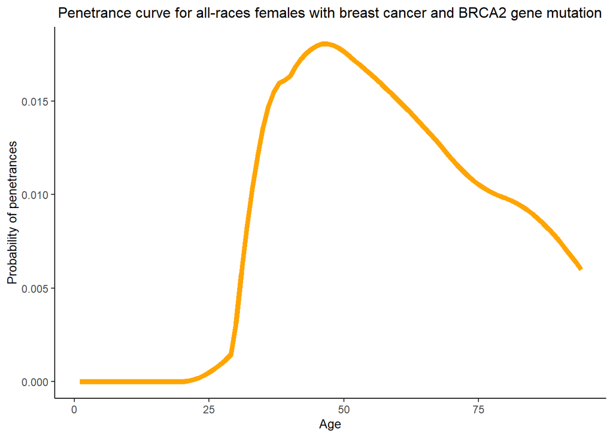

```r
vector_1 <- array["Breast","BRCA2","All_Races","Female",]
data_1 <- data.frame(age = c(1:94), penectrance = vector_1)

ggplot(data_1) +
  geom_line(aes(x = age, y = penectrance), color = "orange", lwd = 2) +
  ggtitle("Penetrance curve for all-races females with breast cancer and BRCA2 gene mutation") +
  xlab("Age") +
  ylab("Probability of penetrances") +
  theme(plot.title = element_text(hjust = 0.5, size = 12),
        axis.text = element_text(size = 9),
        axis.title = element_text(size = 10),
        panel.background = element_blank(),
        axis.line = element_line(color = "black"))
```

- **Question**: Subset the array for the penetrances associated with `Colorectal` cancer and the `PALB2` gene for an Asian male. What is the probability that a person from this subpopulation at age 50 will develop colorectal cancer in the next 10 years given that he has tested positive for a PALB2 mutation but is otherwise disease free?

*Hint: The probability over a period of time is calculated by summing the yearly risks.*

**Solutions**:

```r
vector_2 <- array["Colorectal","PALB2","Asian","Male",]
```

Therefore, the probability of develoing colorectal for this person in the next 10 years is:

```r
sum(vector_2[50:59])
```

```
## [1] 0.0071847
```

## Family pedigrees

Read in the `.rdata` file `pedigree.rda`. Each `data.frame` represents a family. Each individual is uniquely identified by the first column called `ID`. Their sex is coded as `0` for females and `1` for males. Individuals’ mother and father are indicated in the `MotherID` and `FatherID` columns. A value of `NA` in these columns means that this person is a so-called ‘founder’ or that a certain parent is missing.

In the following exercises, you are encouraged to modularise and comment on your code.

- **Question**: Write an R function(s) to count the number of unique nuclear families there are in a certain pedigree. A nuclear family is defined as the set of two parents and all of their children.

  **Solutions**:

```r
pedigree <- load(file = "C:/Users/jh2874/Box/Jiaming Huang/interview/pedigree.rda")

# According to the definition of a nuclear family, the number of unique nuclear families equals to the number of unique pair of parents.
nuclear_family_count <- function(x){
  pedigree_data <- get(x)
  nrow(unique(pedigree_data[!is.na(pedigree_data$MotherID), c("MotherID", "FatherID")]))
}

# so for example, if we want to know the unique number of nuclear family for fam100, we can call the function created above as below
nuclear_family_count("fam100")
```

```
## [1] 26
```

- **Question**: Report the number of nuclear families for the pedigrees contained in the `.rda` file.

  **Solutions**:

```r
sapply(pedigree, nuclear_family_count)
```

```
##  fam10  fam50  fam75 fam100
##      4     10     18     26
```